# Práctica 2 de inferencia multivariante y ACP

## Problema 2

En el siguiente [enlace](https://github.com/igmuib/Practica_AD/blob/main/problema1_ACP.csv) encontraréis datos de España correspondientes al año 2021, organizados en 7 variables: 4 relacionadas con el uso de las tecnologías de la información y la comunicación (TIC) en las empresas, y 3 vinculadas al uso de estas tecnologías por la población y al equipamiento tecnológico de los hogares. Las variables registradas son las siguientes:

`ebroad`: porcentaje de empresas con acceso a Internet de banda ancha.

`esales`: porcentaje de empresas que realizan ventas electrónicas.

`esocmedia`: porcentaje de empresas que utilizan redes sociales.

`eweb`: porcentaje de empresas con sitio web.

`hbroad`: porcentaje de hogares con acceso a Internet de banda ancha.

`hiacc`: porcentaje de hogares con acceso general a Internet, independientemente del tipo de conexión.

`iuse`: porcentaje de individuos que utilizan Internet.

### a. Realizad un análisis exploratorio de los datos, acompañado de un resumen de las observaciones más relevantes en relación con el contexto del problema, para ello crea una variable `region` con los siguientes niveles:

- Europa Occidental” = c(“BE”, “FR”, “DE”, “AT”, “NL”, “LU”, “IE”),
- Europa del Sur” = c(“ES”, “IT”, “PT”, “EL”, “CY”, “MT”),
- “Europa del Este” = c(“CZ”, “BG”, “HU”, “PL”, “RO”, “SK”),
- “Países Nórdicos” = c(“DK”, “SE”, “FI”, “NO”),
- “Países Bálticos” = c(“EE”, “LV”, “LT”)

Aseguraos de incluir, un análisis de la matriz de correlaciones.

#### Respuesta

Cargamos los datos del problema

```r
library(readr)
datos <- read_csv("problema1_ACP.csv")
```

Primero veamos las correlaciones entre las cariables sin hacer distinción por regiones,

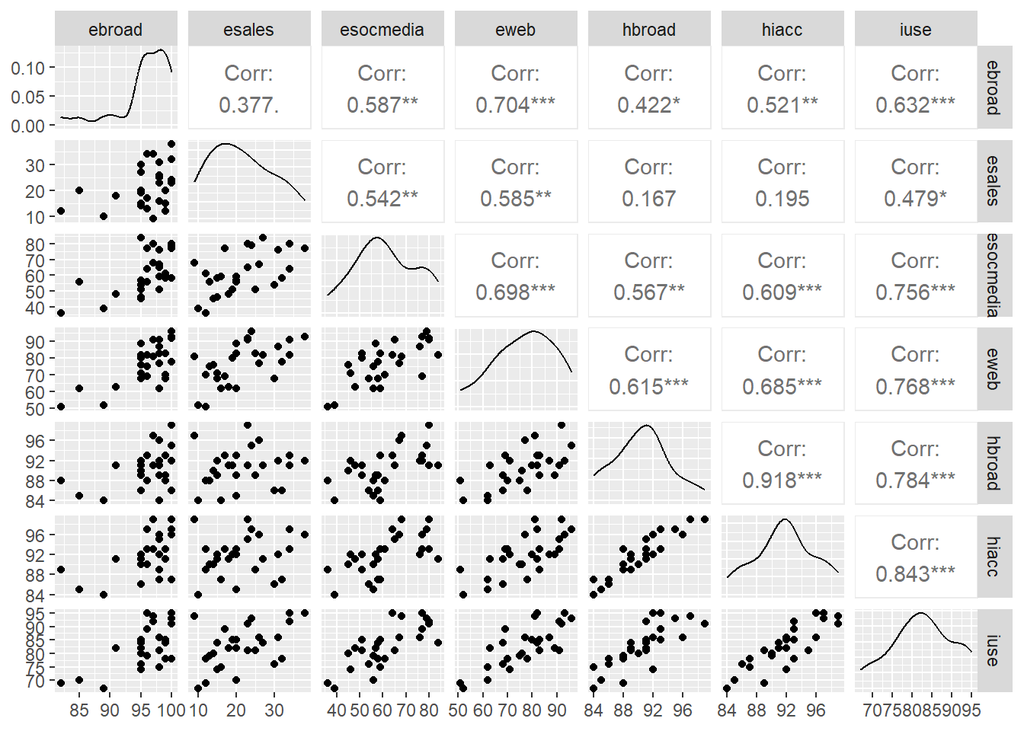

```r
library(GGally)

vars <- datos %>% select(where(is.numeric))
ggpairs(vars)
```

Clasificamos los datos en función de los vectores definidos anteriormente,

```r
datos$region <- with(datos,
                     ifelse(datos$...1 %in% c("BE","FR","DE","AT","NL","LU","IE"), "Europa Occidental",
                     ifelse(datos$...1 %in% c("ES","IT","PT","EL","CY","MT"), "Europa del Sur",
                     ifelse(datos$...1 %in% c("CZ","BG","HU","PL","RO","SK"), "Europa del Este",
                     ifelse(datos$...1 %in% c("DK","SE","FI","NO"), "Países Nórdicos",
                     ifelse(datos$...1 %in% c("EE","LV","LT"), "Países Bálticos",
                            NA))))))

datos_Occidental <- datos %>%
  filter(region == "Europa Occidental")

datos_Sur <- datos %>%
  filter(region == "Europa del Sur")

datos_Este <- datos %>%
  filter(region == "Europa del Este")

datos_Nordicos <- datos %>%
  filter(region == "Países Nórdicos")

datos_Balticos <- datos %>%
  filter(region == "Países Bálticos")
```

Vamos a mirar las correlaciones dentro de cada región,

Europa Occidental

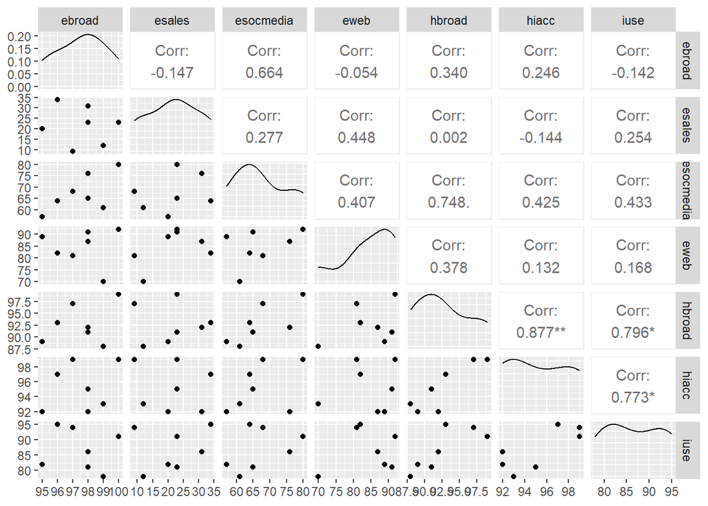

```r
vars_occ <- datos_Occidental %>% select(where(is.numeric))
ggpairs(vars_occ)
```

Europa del Este

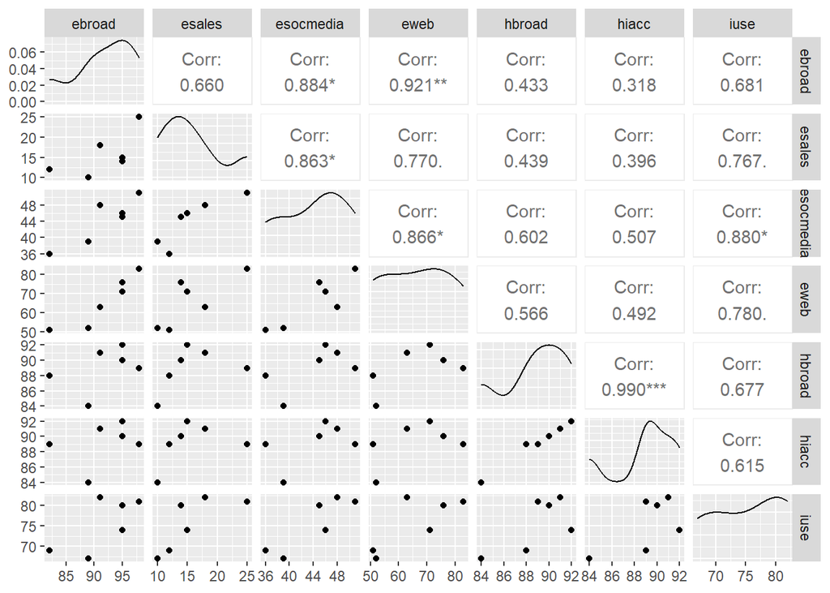

```r
vars_est <- datos_Este %>% select(where(is.numeric))
ggpairs(vars_est)
```

Europa del Sur

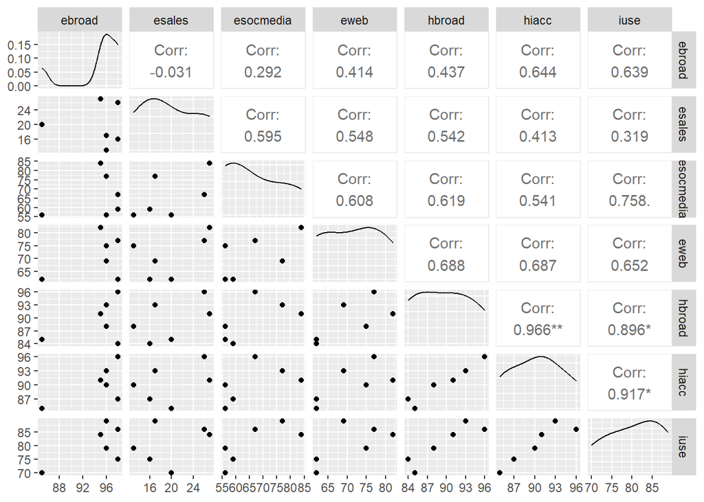

```r
vars_sur <- datos_Sur %>% select(where(is.numeric))
ggpairs(vars_sur)
```

Paises Bálticos

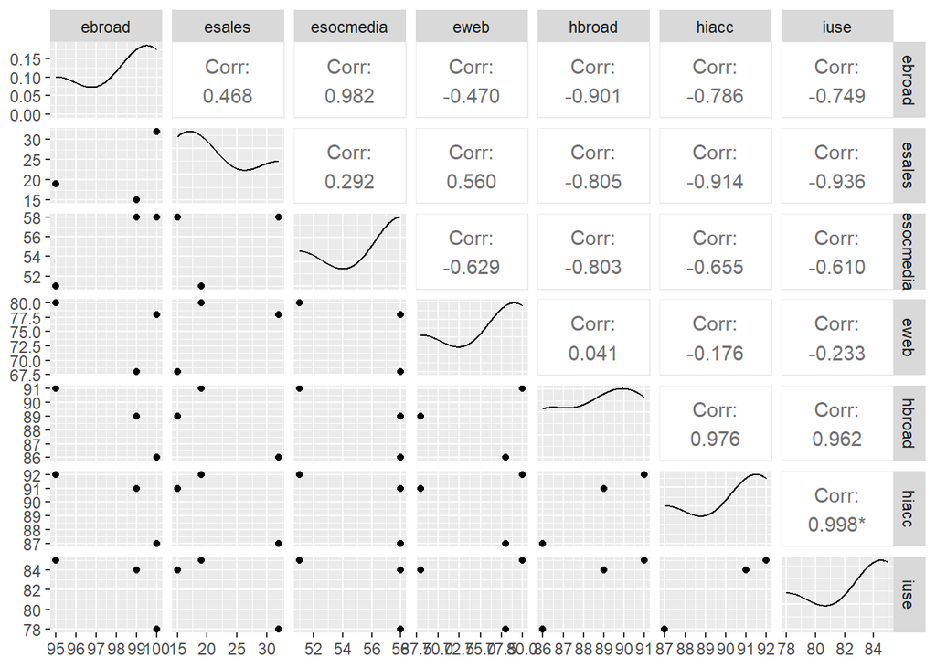

```r
vars_bal <- datos_Balticos %>% select(where(is.numeric))
ggpairs(vars_bal)
```

Paises Nórdicos

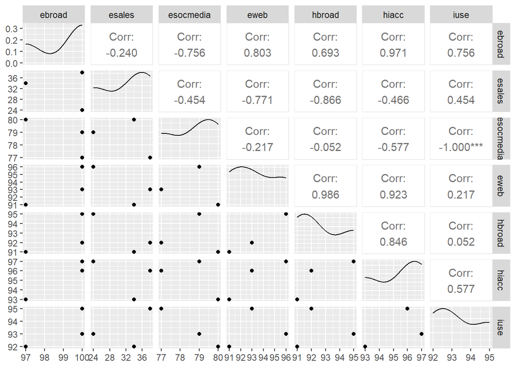

```r
vars_nor <- datos_Nordicos %>% select(where(is.numeric))
ggpairs(vars_nor)
```

Ahora vamos a estudiar las correlaciones entre los distintos grupos,

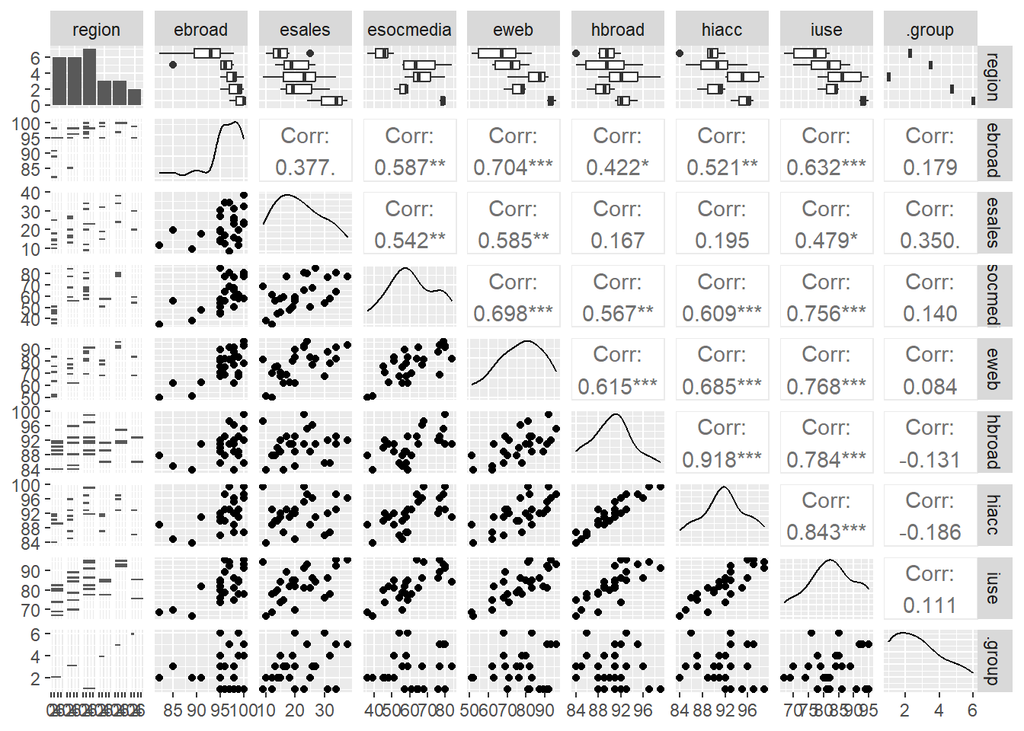

```r
datos_2 <- datos %>% select(-...1) %>% group_by(region)

vars_total <- datos_2 %>% select(where(is.numeric))
ggpairs(vars_total)
```

### b. Realizad una reducción del número de variables utilizando un Análisis de Componentes Principales (PCA). Justificad si trabajaréis con la matriz de covarianzas o la de correlaciones, considerando las características de los datos. Evaluad la idoneidad de la reducción propuesta, indicando claramente el criterio empleado para seleccionar el número de componentes principales a retener. Finalmente, interpretad las componentes principales seleccionadas, describiendo qué representan en el contexto de los datos y cómo contribuyen al análisis.

#### Respuesta

Aunque los valores están todos en la misma escala, ya que son porcentajes, presentan variabilidad entre ellos, por lo que consideraremos la matriz de correlaciones pra trabajar.

```r
library("factoextra")
pca=prcomp(vars,scale=TRUE)
lambdas=get_eigenvalue(pca)
lambdas
```

```
      eigenvalue variance.percent cumulative.variance.percent
Dim.1 4.64389223       66.3413175                    66.34132
Dim.2 1.10116015       15.7308594                    82.07218
Dim.3 0.54694711        7.8135301                    89.88571
Dim.4 0.32755960        4.6794228                    94.56513
Dim.5 0.19113964        2.7305663                    97.29570
Dim.6 0.12374504        1.7677862                    99.06348
Dim.7 0.06555623        0.9365176                   100.00000
```

```r
pca$rotation
```

```
                 PC1         PC2         PC3         PC4         PC5
ebroad    -0.3457029  0.18603126 -0.83607119  0.02063918  0.30618433
esales    -0.2558341  0.69677230  0.44360293  0.29488939  0.29192052
esocmedia -0.3890417  0.18243899  0.12833451 -0.85583504 -0.22628932
eweb      -0.4133127  0.17600791 -0.11536250  0.37833440 -0.76769855
hbroad    -0.3768942 -0.47743231  0.22962967  0.13540079  0.05578843
hiacc     -0.4015226 -0.42549670  0.08788062  0.13436840  0.05469620
iuse      -0.4354169 -0.08154087  0.11819629 -0.02520905  0.41756631
                   PC6          PC7
ebroad    -0.229333263 -0.009913242
esales    -0.255355549  0.122024352
esocmedia -0.114549549  0.045943252
eweb       0.200265265 -0.110820212
hbroad    -0.547765685 -0.505753273
hiacc     -0.009434241  0.793015506
iuse       0.727210954 -0.293189218
```

Como hemos visto antes, las 2 primeras componentes principales son las que acumulan la mayoría de la varianza total (un 82%). En la primera componente, vemos que es una combinación lineal de las 7 primeras variables con un peso más o menos similar para cada variable. Por otro lado, la segunda componente le da un mayor peso a las ventas electrónicas realizadas por empresas y a las variables relacionadas con la electrónica en hogares.

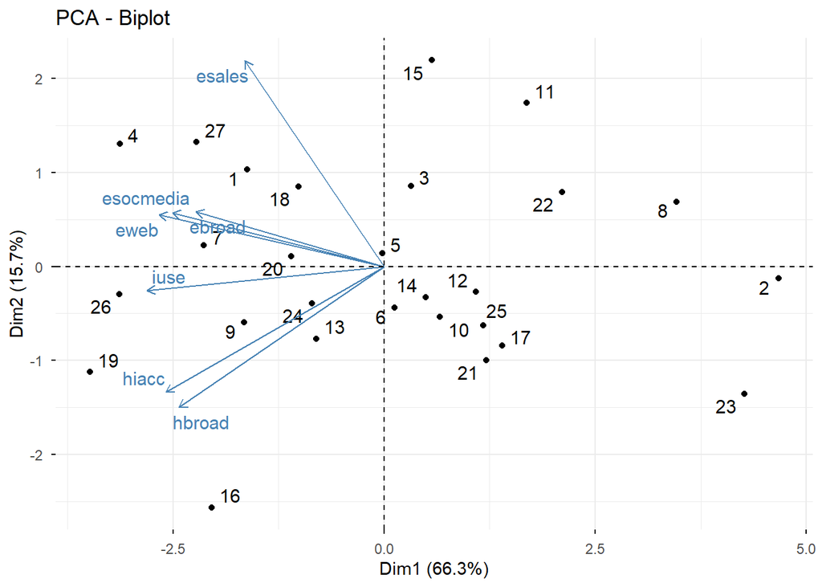

```r
library("factoextra")
fviz_pca_biplot(pca,repel=TRUE)
```